# Ordinal Transformer Classifier for Article Bias Prediction

- Treat political bias as an ordered spectrum: left < center < right.
- Use a RoBERTa-family transformer for contextual embeddings instead of an LSTM trained from scratch.
- Use cumulative ordinal targets, where left = (1, 0, 0), center = (1, 1, 0), and right = (1, 1, 1), with binary cross-entropy over the ordinal outputs.
- Report both standard classification metrics and distance-aware metrics so left/right mistakes are penalized more than left/center or center/right mistakes.

```python
import os
import json
import random
from pathlib import Path

import numpy as np
import pandas as pd
import torch
from torch import nn
from torch.utils.data import Dataset

from sklearn.metrics import (
    accuracy_score,
    classification_report,
    confusion_matrix,
    mean_absolute_error,
    mean_squared_error,
)

from transformers import (
    AutoConfig,
    AutoModel,
    AutoTokenizer,
    Trainer,
    TrainingArguments,
    set_seed,
)

SEED = 42
set_seed(SEED)
random.seed(SEED)
np.random.seed(SEED)
torch.manual_seed(SEED)

print(f"PyTorch: {torch.__version__}")
print(f"CUDA available: {torch.cuda.is_available()}")
```

```
PyTorch: 2.11.0+cu130
CUDA available: True
```

## 1. Load Article-Bias Data

The original notebook used an ad hoc random split after loading every JSON file. Here we use the dataset's provided random split files so experiments are reproducible and comparable.

```python
BASE_DIR = Path('/home/neogrendal')
DATASET_DIR = BASE_DIR / 'Article-Bias-Prediction-main'
JSON_DIR = DATASET_DIR / 'data' / 'jsons'
SPLIT_DIR = DATASET_DIR / 'data' / 'splits' / 'random'

LABEL_ORDER = ['left', 'center', 'right']
LABEL_TO_ID = {label: i for i, label in enumerate(LABEL_ORDER)}
ID_TO_LABEL = {i: label for label, i in LABEL_TO_ID.items()}

# The TSV bias column in this copy follows 0=left, 1=center, 2=right.
BIAS_ID_TO_TEXT = {0: 'left', 1: 'center', 2: 'right'}


def load_split(split_name):
    split_path = SPLIT_DIR / f'{split_name}.tsv'
    split_df = pd.read_csv(split_path, sep='	')
    rows = []

    for item in split_df.itertuples(index=False):
        article_path = JSON_DIR / f'{item.ID}.json'
        with open(article_path, encoding='utf-8') as f:
            article = json.load(f)

        label_id = int(item.bias)
        label_text = BIAS_ID_TO_TEXT[label_id]
        text = article.get('content') or article.get('content_original') or article.get('title') or ''

        if isinstance(text, str) and text.strip():
            rows.append({
                'ID': item.ID,
                'text': text,
                'label': label_id,
                'label_text': label_text,
                'title': article.get('title', ''),
                'source': article.get('source', ''),
            })

    return pd.DataFrame(rows)

train_df = load_split('train')
valid_df = load_split('valid')
test_df = load_split('test')

for name, frame in [('train', train_df), ('valid', valid_df), ('test', test_df)]:
    print(name, frame.shape)
    print(frame['label_text'].value_counts().reindex(LABEL_ORDER))
```

```
train (27978, 6)
label_text
left       9750
center     7988
right     10240
Name: count, dtype: int64
valid (6996, 6)
label_text
left      2438
center    1998
right     2560
Name: count, dtype: int64
test (1300, 6)
label_text
left      402
center    299
right     599
Name: count, dtype: int64
```

## 2. Ordinal Cumulative Encoding

The labels are not independent categories; they sit on a political spectrum. The cumulative target below follows the review suggestion:

- left = (1, 0, 0)
- center = (1, 1, 0)
- right = (1, 1, 1)

At inference time, the predicted class is recovered by thresholding each sigmoid output at 0.5 and counting the active cumulative bits.

```python
def to_ordinal_targets(label_ids, num_classes=3):
    label_ids = np.asarray(label_ids, dtype=np.int64)
    thresholds = np.arange(num_classes, dtype=np.int64)
    return (label_ids[:, None] >= thresholds[None, :]).astype(np.float32)


def ordinal_probs_to_labels(probabilities, threshold=0.5):
    active_bits = (probabilities >= threshold).astype(np.int64).sum(axis=1)
    # left has one active bit, center two, right three.
    return np.clip(active_bits - 1, 0, len(LABEL_ORDER) - 1)

example = pd.DataFrame({
    'label': LABEL_ORDER,
    'class_id': [LABEL_TO_ID[label] for label in LABEL_ORDER],
    'ordinal_target': to_ordinal_targets([0, 1, 2]).tolist(),
})
example
```

|  | label | class_id | ordinal_target |
| --- | --- | --- | --- |
| 0 | left | 0 | [1.0, 0.0, 0.0] |
| 1 | center | 1 | [1.0, 1.0, 0.0] |
| 2 | right | 2 | [1.0, 1.0, 1.0] |

## 3. Tokenization Dataset

RoBERTa uses subword tokenization and contextual embeddings. This replaces the original word-level Keras tokenizer and learned-from-scratch embedding layer.

```python
MODEL_NAME = 'distilroberta-base'  # RoBERTa-family encoder; lighter than roberta-base.
MAX_LENGTH = 128
RUN_FULL_TRAINING = True
MAX_TRAIN_SAMPLES = None if RUN_FULL_TRAINING else 2000
MAX_VALID_SAMPLES = None if RUN_FULL_TRAINING else 500
MAX_TEST_SAMPLES = None if RUN_FULL_TRAINING else 500
FREEZE_ENCODER = False


def stratified_sample(frame, n, seed=SEED):
    if n is None or len(frame) <= n:
        return frame.reset_index(drop=True)
    per_class = max(1, n // len(LABEL_ORDER))
    sampled = (
        frame.groupby('label', group_keys=False)
             .apply(lambda group: group.sample(min(len(group), per_class), random_state=seed))
             .sample(frac=1, random_state=seed)
             .reset_index(drop=True)
    )
    return sampled

train_df_model = stratified_sample(train_df, MAX_TRAIN_SAMPLES)
valid_df_model = stratified_sample(valid_df, MAX_VALID_SAMPLES)
test_df_model = stratified_sample(test_df, MAX_TEST_SAMPLES)

print('Modeling data sizes:')
print({'train': len(train_df_model), 'valid': len(valid_df_model), 'test': len(test_df_model)})
print(f'Encoder frozen: {FREEZE_ENCODER}')

tokenizer = AutoTokenizer.from_pretrained(MODEL_NAME)


class ArticleBiasOrdinalDataset(Dataset):
    def __init__(self, frame, tokenizer, max_length=128):
        self.frame = frame.reset_index(drop=True)
        self.tokenizer = tokenizer
        self.max_length = max_length
        self.ordinal_targets = to_ordinal_targets(self.frame['label'].values)

    def __len__(self):
        return len(self.frame)

    def __getitem__(self, idx):
        row = self.frame.iloc[idx]
        encoded = self.tokenizer(
            row['text'],
            truncation=True,
            max_length=self.max_length,
            padding='max_length',
            return_tensors='pt',
        )
        item = {key: value.squeeze(0) for key, value in encoded.items()}
        item['labels'] = torch.tensor(self.ordinal_targets[idx], dtype=torch.float32)
        item['class_label'] = torch.tensor(int(row['label']), dtype=torch.long)
        return item

train_dataset = ArticleBiasOrdinalDataset(train_df_model, tokenizer, MAX_LENGTH)
valid_dataset = ArticleBiasOrdinalDataset(valid_df_model, tokenizer, MAX_LENGTH)
test_dataset = ArticleBiasOrdinalDataset(test_df_model, tokenizer, MAX_LENGTH)
```

```
Modeling data sizes:
{'train': 27978, 'valid': 6996, 'test': 1300}
Encoder frozen: False
```

## 4. RoBERTa With Ordinal Head

The model outputs three ordinal logits instead of a three-way softmax. Binary cross-entropy trains each cumulative decision, so a far-off error usually requires more wrong ordinal decisions than an adjacent-class error.

```python
class OrdinalRobertaClassifier(nn.Module):
    def __init__(self, model_name, num_ordinal_outputs=3, dropout=0.1, freeze_encoder=False):
        super().__init__()
        self.config = AutoConfig.from_pretrained(model_name)
        self.encoder = AutoModel.from_pretrained(model_name, config=self.config)
        hidden_size = self.config.hidden_size
        self.dropout = nn.Dropout(dropout)
        self.classifier = nn.Linear(hidden_size, num_ordinal_outputs)
        self.loss_fn = nn.BCEWithLogitsLoss()

        if freeze_encoder:
            for parameter in self.encoder.parameters():
                parameter.requires_grad = False

    def forward(self, input_ids=None, attention_mask=None, labels=None, **kwargs):
        outputs = self.encoder(input_ids=input_ids, attention_mask=attention_mask, **kwargs)
        cls_embedding = outputs.last_hidden_state[:, 0]
        logits = self.classifier(self.dropout(cls_embedding))

        loss = None
        if labels is not None:
            loss = self.loss_fn(logits, labels.float())

        return {'loss': loss, 'logits': logits}

model = OrdinalRobertaClassifier(
    MODEL_NAME,
    num_ordinal_outputs=len(LABEL_ORDER),
    freeze_encoder=FREEZE_ENCODER,
)
trainable_params = sum(p.numel() for p in model.parameters() if p.requires_grad)
total_params = sum(p.numel() for p in model.parameters())
print(f'Trainable parameters: {trainable_params:,} / {total_params:,}')
```

[output not shown]

```
Trainable parameters: 82,120,707 / 82,120,707
```

## 5. Distance-Aware Metrics

Standard accuracy is still useful, but it treats every mistake equally. Mean absolute error on class IDs gives adjacent mistakes a penalty of 1 and left-right mistakes a penalty of 2. Squared distance makes far-off errors even more visible.

```python
def compute_metrics(eval_pred):
    logits, labels = eval_pred
    probabilities = 1 / (1 + np.exp(-logits))
    y_pred = ordinal_probs_to_labels(probabilities)
    y_true = ordinal_probs_to_labels(labels)

    return {
        'accuracy': accuracy_score(y_true, y_pred),
        'ordinal_mae': mean_absolute_error(y_true, y_pred),
        'ordinal_mse': mean_squared_error(y_true, y_pred),
        'severe_error_rate': float(np.mean(np.abs(y_true - y_pred) == 2)),
    }
```

## 6. Fine-Tune

```python
OUTPUT_DIR = BASE_DIR / 'bias_ordinal_roberta_model'

training_args = TrainingArguments(
    output_dir=str(OUTPUT_DIR),
    eval_strategy='epoch',
    save_strategy='no' if not RUN_FULL_TRAINING else 'epoch',
    learning_rate=2e-5,
    per_device_train_batch_size=4,
    per_device_eval_batch_size=8,
    gradient_accumulation_steps=2,
    num_train_epochs=1 if not RUN_FULL_TRAINING else 3,
    weight_decay=0.01,
    load_best_model_at_end=RUN_FULL_TRAINING,
    metric_for_best_model='ordinal_mae',
    greater_is_better=False,
    logging_steps=25,
    report_to='none',
    seed=SEED,
    fp16=torch.cuda.is_available(),
)

trainer = Trainer(
    model=model,
    args=training_args,
    train_dataset=train_dataset,
    eval_dataset=valid_dataset,
    compute_metrics=compute_metrics,
)

trainer.train()
```

[10494/10494 13:46, Epoch 3/3]

| Epoch | Training Loss | Validation Loss | Accuracy | Ordinal Mae | Ordinal Mse | Severe Error Rate |
| --- | --- | --- | --- | --- | --- | --- |
| 1 | 0.390932 | 0.273601 | 0.741424 | 0.326329 | 0.461835 | 0.067753 |
| 2 | 0.404751 | 0.230020 | 0.779731 | 0.288308 | 0.424385 | 0.068039 |
| 3 | 0.368875 | 0.254957 | 0.788879 | 0.276444 | 0.407090 | 0.065323 |

```
TrainOutput(global_step=10494, training_loss=0.4396430415972678, metrics={'train_runtime': 826.9495, 'train_samples_per_second': 101.498, 'train_steps_per_second': 12.69, 'total_flos': 0.0, 'train_loss': 0.4396430415972678, 'epoch': 3.0})
```

## 7. Evaluate on Test Set

This section reports both the normal classification report and ordinal-distance metrics requested by the reviewer.

```python
test_output = trainer.predict(test_dataset)
test_logits = test_output.predictions
test_probs = 1 / (1 + np.exp(-test_logits))
y_pred = ordinal_probs_to_labels(test_probs)
y_true = test_df_model['label'].values

print('Distance-aware metrics:')
print({
    'accuracy': accuracy_score(y_true, y_pred),
    'ordinal_mae': mean_absolute_error(y_true, y_pred),
    'ordinal_mse': mean_squared_error(y_true, y_pred),
    'severe_error_rate': float(np.mean(np.abs(y_true - y_pred) == 2)),
})

print('\nClassification report:')
print(classification_report(y_true, y_pred, target_names=LABEL_ORDER))

cm = confusion_matrix(y_true, y_pred, labels=[0, 1, 2])
cm_df = pd.DataFrame(cm, index=[f'true_{x}' for x in LABEL_ORDER], columns=[f'pred_{x}' for x in LABEL_ORDER])
cm_df
```

```
Distance-aware metrics:
{'accuracy': 0.7192307692307692, 'ordinal_mae': 0.39, 'ordinal_mse': 0.6084615384615385, 'severe_error_rate': 0.10923076923076923}

Classification report:
              precision    recall  f1-score   support

        left       0.76      0.67      0.71       402
      center       0.58      0.96      0.72       299
       right       0.85      0.63      0.72       599

    accuracy                           0.72      1300
   macro avg       0.73      0.76      0.72      1300
weighted avg       0.76      0.72      0.72      1300
```

|  | pred_left | pred_center | pred_right |
| --- | --- | --- | --- |
| true_left | 271 | 71 | 60 |
| true_center | 4 | 288 | 7 |
| true_right | 82 | 141 | 376 |

## 10. Performance Visualizations and Conclusions

The confusion matrix shows that the model is strongest at identifying center articles and generally separates the extremes, but right articles are sometimes pulled toward center. That pattern is preferable to many direct right-left confusions, yet the severe-error rate indicates that more work is still needed before using the model in a high-stakes setting. Next improvements would be threshold tuning for the ordinal bits, class-specific calibration, and comparing this cumulative head against a standard RoBERTa softmax baseline.

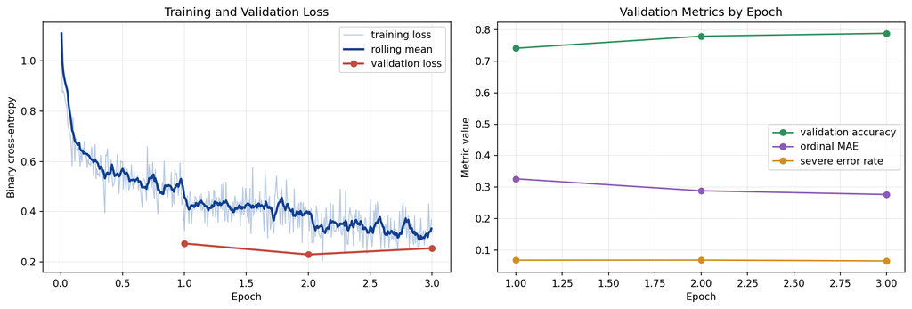

```python
# Performance curves from the saved Trainer log history.
trainer_state_path = OUTPUT_DIR / 'checkpoint-10494' / 'trainer_state.json'
with open(trainer_state_path, encoding='utf-8') as f:
    trainer_state = json.load(f)

log_df = pd.DataFrame(trainer_state['log_history'])
train_log_df = log_df.dropna(subset=['loss']).copy()
eval_log_df = log_df.dropna(subset=['eval_loss']).copy()

fig, axes = plt.subplots(1, 2, figsize=(13, 4.5))
axes[0].plot(train_log_df['epoch'], train_log_df['loss'], alpha=0.35, linewidth=1, label='training loss')
axes[0].plot(train_log_df['epoch'], train_log_df['loss'].rolling(8, min_periods=1).mean(), linewidth=2.2, label='rolling mean')
axes[0].plot(eval_log_df['epoch'], eval_log_df['eval_loss'], marker='o', linewidth=2, label='validation loss')
axes[0].set_title('Training and Validation Loss')
axes[0].set_xlabel('Epoch')
axes[0].set_ylabel('Binary cross-entropy')
axes[0].grid(True, alpha=0.25)
axes[0].legend()

axes[1].plot(eval_log_df['epoch'], eval_log_df['eval_accuracy'], marker='o', label='validation accuracy')
axes[1].plot(eval_log_df['epoch'], eval_log_df['eval_ordinal_mae'], marker='o', label='ordinal MAE')
axes[1].plot(eval_log_df['epoch'], eval_log_df['eval_severe_error_rate'], marker='o', label='severe error rate')
axes[1].set_title('Validation Metrics by Epoch')
axes[1].set_xlabel('Epoch')
axes[1].set_ylabel('Metric value')
axes[1].grid(True, alpha=0.25)
axes[1].legend()
plt.tight_layout()
plt.show()
```

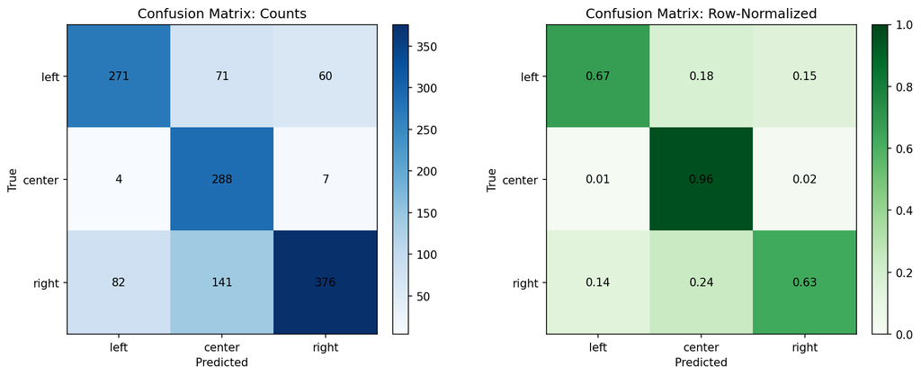

```python
# Confusion-matrix visualizations for the full test set.
cm = np.array([
    [271, 71, 60],
    [4, 288, 7],
    [82, 141, 376],
])
class_labels = ['left', 'center', 'right']

fig, axes = plt.subplots(1, 2, figsize=(12, 4.8))
im = axes[0].imshow(cm, cmap='Blues')
axes[0].set_title('Confusion Matrix: Counts')
axes[0].set_xticks(range(3), labels=class_labels)
axes[0].set_yticks(range(3), labels=class_labels)
axes[0].set_xlabel('Predicted')
axes[0].set_ylabel('True')
for i in range(3):
    for j in range(3):
        axes[0].text(j, i, str(cm[i, j]), ha='center', va='center', color='black')
fig.colorbar(im, ax=axes[0], fraction=0.046, pad=0.04)

cm_norm = cm / cm.sum(axis=1, keepdims=True)
im2 = axes[1].imshow(cm_norm, cmap='Greens', vmin=0, vmax=1)
axes[1].set_title('Confusion Matrix: Row-Normalized')
axes[1].set_xticks(range(3), labels=class_labels)
axes[1].set_yticks(range(3), labels=class_labels)
axes[1].set_xlabel('Predicted')
axes[1].set_ylabel('True')
for i in range(3):
    for j in range(3):
        axes[1].text(j, i, f'{cm_norm[i, j]:.2f}', ha='center', va='center', color='black')
fig.colorbar(im2, ax=axes[1], fraction=0.046, pad=0.04)
plt.tight_layout()
plt.show()
```

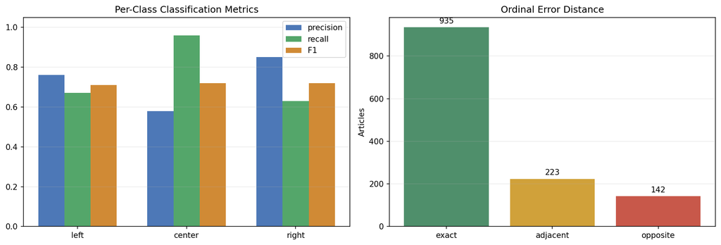

| metric | value |
| --- | --- |
| accuracy | 0.719231 |
| ordinal_mae | 0.390000 |
| ordinal_mse | 0.608462 |
| severe_error_rate | 0.109231 |

| class | precision | recall | f1 | support |
| --- | --- | --- | --- | --- |
| left | 0.76 | 0.67 | 0.71 | 402 |
| center | 0.58 | 0.96 | 0.72 | 299 |
| right | 0.85 | 0.63 | 0.72 | 599 |

```python
# Per-class metrics and ordinal error-distance chart.
class_metric_df = pd.DataFrame({
    'class': ['left', 'center', 'right'],
    'precision': [0.76, 0.58, 0.85],
    'recall': [0.67, 0.96, 0.63],
    'f1': [0.71, 0.72, 0.72],
    'support': [402, 299, 599],
})

fig, axes = plt.subplots(1, 2, figsize=(13, 4.5))
x = np.arange(len(class_metric_df))
width = 0.24
axes[0].bar(x - width, class_metric_df['precision'], width, label='precision')
axes[0].bar(x, class_metric_df['recall'], width, label='recall')
axes[0].bar(x + width, class_metric_df['f1'], width, label='F1')
axes[0].set_title('Per-Class Classification Metrics')
axes[0].set_xticks(x, labels=class_metric_df['class'])
axes[0].set_ylim(0, 1.05)
axes[0].grid(True, axis='y', alpha=0.25)
axes[0].legend()

dist_counts = {0: 0, 1: 0, 2: 0}
for i in range(3):
    for j in range(3):
        dist_counts[abs(i - j)] += int(cm[i, j])
axes[1].bar(['exact', 'adjacent', 'opposite'], [dist_counts[0], dist_counts[1], dist_counts[2]])
axes[1].set_title('Ordinal Error Distance')
axes[1].set_ylabel('Articles')
axes[1].grid(True, axis='y', alpha=0.25)
for idx, value in enumerate([dist_counts[0], dist_counts[1], dist_counts[2]]):
    axes[1].text(idx, value + max(dist_counts.values()) * 0.02, str(value), ha='center')
plt.tight_layout()
plt.show()

summary_df = pd.DataFrame({
    'metric': ['accuracy', 'ordinal_mae', 'ordinal_mse', 'severe_error_rate'],
    'value': [0.7192307692307692, 0.39, 0.6084615384615385, 0.10923076923076923],
})
display(summary_df)
display(class_metric_df)
```

## 8. Prediction Helper

The helper returns cumulative probabilities, the decoded class, confidence, and the ordinal score. The ordinal score can also be interpreted as a continuous left-to-right position.

```python
def predict_bias(text):
    model.eval()
    encoded = tokenizer(
        text,
        truncation=True,
        max_length=MAX_LENGTH,
        padding='max_length',
        return_tensors='pt',
    )
    device = next(model.parameters()).device
    encoded = {key: value.to(device) for key, value in encoded.items()}

    with torch.no_grad():
        logits = model(**encoded)['logits']
        probs = torch.sigmoid(logits).cpu().numpy()[0]

    predicted_id = int(ordinal_probs_to_labels(probs[None, :])[0])
    ordinal_score = float(np.clip(probs.sum() - 1, 0, 2))

    return {
        'predicted_bias': ID_TO_LABEL[predicted_id],
        'predicted_id': predicted_id,
        'ordinal_score_left_to_right': ordinal_score,
        'cumulative_probabilities': {f'bit_{i}': float(value) for i, value in enumerate(probs)},
    }

sample_text = test_df_model.iloc[0]['text']
predict_bias(sample_text)
```

```
{'predicted_bias': 'right',
 'predicted_id': 2,
 'ordinal_score_left_to_right': 1.4394118785858154,
 'cumulative_probabilities': {'bit_0': 0.9999008178710938,
  'bit_1': 0.9348725080490112,
  'bit_2': 0.5046385526657104}}
```

## 9. Save Artifacts

Save the fine-tuned transformer, tokenizer, and metadata needed to explain the revised approach.

```python
trainer.save_model(str(OUTPUT_DIR))
tokenizer.save_pretrained(str(OUTPUT_DIR))

metadata = {
    'base_model': MODEL_NAME,
    'approach': 'RoBERTa-family encoder with cumulative ordinal classification head',
    'crash_safe_defaults': {
        'run_full_training': RUN_FULL_TRAINING,
        'max_train_samples': MAX_TRAIN_SAMPLES,
        'max_valid_samples': MAX_VALID_SAMPLES,
        'max_test_samples': MAX_TEST_SAMPLES,
        'freeze_encoder': FREEZE_ENCODER,
        'max_length': MAX_LENGTH,
    },
    'label_order': LABEL_ORDER,
    'ordinal_encoding': {
        'left': [1, 0, 0],
        'center': [1, 1, 0],
        'right': [1, 1, 1],
    },
    'metrics': ['accuracy', 'ordinal_mae', 'ordinal_mse', 'severe_error_rate'],
}

with open(OUTPUT_DIR / 'ordinal_metadata.json', 'w', encoding='utf-8') as f:
    json.dump(metadata, f, indent=2)

print(f'Saved model and metadata to {OUTPUT_DIR}')
```

```
Saved model and metadata to /home/neogrendal/bias_ordinal_roberta_model
```

## 11. Baseline vs Updated Model Comparison

This section compares the original presentation's BiLSTM baseline against the updated ordinal DistilRoBERTa model. The transformer model improves test accuracy from 61.4% to 71.9%, with the largest F1 gain on center articles. It also adds distance-aware evaluation: ordinal MAE is 0.390 on the 0=left to 2=right scale, and severe opposite-pole errors occur in 10.9% of test cases.

On the newly scraped articles, the updated model changes the main source-level story. The old LSTM report found FOX was often predicted left; the new ordinal RoBERTa report predicts FOX mostly right. This suggests the transformer upgrade reduced the most visible out-of-distribution failure from the baseline, though these are still model predictions rather than ground-truth article labels.

[figure not shown]

[output not shown]

```python
# Baseline vs updated model comparison charts.
comparison_df = pd.DataFrame([
    {'Model': 'BiLSTM baseline', 'Accuracy': 0.614, 'Left F1': 0.61, 'Center F1': 0.58, 'Right F1': 0.64},
    {'Model': 'Ordinal DistilRoBERTa', 'Accuracy': 0.7192307692307692, 'Left F1': 0.71, 'Center F1': 0.72, 'Right F1': 0.72},
])

fig, axes = plt.subplots(1, 2, figsize=(13, 4.7))
axes[0].bar(comparison_df['Model'], comparison_df['Accuracy'])
axes[0].set_title('Test Accuracy Improvement')
axes[0].set_ylim(0, 0.85)
axes[0].set_ylabel('Accuracy')
axes[0].grid(True, axis='y', alpha=0.25)
for idx, value in enumerate(comparison_df['Accuracy']):
    axes[0].text(idx, value + 0.02, f'{value:.1%}', ha='center')

classes = ['Left', 'Center', 'Right']
x = np.arange(len(classes))
width = 0.34
lstm_f1 = [0.61, 0.58, 0.64]
roberta_f1 = [0.71, 0.72, 0.72]
axes[1].bar(x - width / 2, lstm_f1, width, label='BiLSTM baseline')
axes[1].bar(x + width / 2, roberta_f1, width, label='Ordinal DistilRoBERTa')
axes[1].set_title('Per-Class F1 Comparison')
axes[1].set_xticks(x, classes)
axes[1].set_ylim(0, 0.85)
axes[1].set_ylabel('F1')
axes[1].grid(True, axis='y', alpha=0.25)
axes[1].legend()
plt.tight_layout()
plt.show()

display(comparison_df)
```

[figure not shown]

[output not shown]

```python
# Distance-aware metrics and new-article source-report differences.
source_comparison = pd.DataFrame([
    {'Source metric': 'FOX right share', 'BiLSTM baseline': 30 / 259, 'Ordinal DistilRoBERTa': 0.749035},
    {'Source metric': 'FOX left share', 'BiLSTM baseline': 133 / 259, 'Ordinal DistilRoBERTa': 0.084942},
    {'Source metric': 'NPR center share', 'BiLSTM baseline': 25 / 80, 'Ordinal DistilRoBERTa': 0.647059},
])

fig, axes = plt.subplots(1, 2, figsize=(12, 4.5))
axes[0].bar(['Ordinal MAE', 'Severe Error Rate'], [0.390, 0.10923076923076923])
axes[0].set_title('Distance-Aware Metrics Added by Ordinal Model')
axes[0].set_ylim(0, 0.5)
axes[0].set_ylabel('Metric value')
axes[0].grid(True, axis='y', alpha=0.25)

x = np.arange(len(source_comparison))
width = 0.34
axes[1].bar(x - width / 2, source_comparison['BiLSTM baseline'], width, label='BiLSTM baseline')
axes[1].bar(x + width / 2, source_comparison['Ordinal DistilRoBERTa'], width, label='Ordinal DistilRoBERTa')
axes[1].set_title('Real-World Source Report Changes')
axes[1].set_xticks(x, source_comparison['Source metric'], rotation=20, ha='right')
axes[1].set_ylim(0, 0.85)
axes[1].set_ylabel('Share of source articles')
axes[1].grid(True, axis='y', alpha=0.25)
axes[1].legend()
plt.tight_layout()
plt.show()

display(source_comparison)
```